# baroth_OriginalHomeworkCode_03

[figure not shown]

Warm Bodies (2013) a.k.a. quality cinema

Note: sorry that I didn’t use the path directly linked to the data on Github. It wasn’t loading correctly.

## Background

This data includes the first name, last name, and gender of the entire population of 1000 people who have survived the zombie apocalypse and are now ekeing out an existence somewhere on the East Coast, along with several other variables (height, weight, age, number of years of education, number of zombies they have killed, and college major

```r
zombiedata <- (read.csv("C:/Users/brook/OneDrive/Documents/2023_Fall/AN588/zombiesdata.csv"))

head(zombiedata)
```

```
##   id first_name last_name gender   height   weight zombies_killed
## 1  1      Sarah    Little Female 62.88951 132.0872              2
## 2  2       Mark    Duncan   Male 67.80277 146.3753              5
## 3  3    Brandon     Perez   Male 72.12908 152.9370              1
## 4  4      Roger   Coleman   Male 66.78484 129.7418              5
## 5  5      Tammy    Powell Female 64.71832 132.4265              4
## 6  6    Anthony     Green   Male 71.24326 152.5246              1
##   years_of_education                           major      age
## 1                  1                medicine/nursing 17.64275
## 2                  3 criminal justice administration 22.58951
## 3                  1                       education 21.91276
## 4                  6                  energy studies 18.19058
## 5                  3                       logistics 21.10399
## 6                  4                  energy studies 21.48355
```

## 1. Calculate the population mean and standard deviation for each quantitative random variable (height, weight, age, number of zombies killed, and years of education).

NOTE: You will not want to use the built in var() and sd() commands as these are for samples.

First write a quick function to calculate standard deviation since we cannot use sd() for a population.

```r
pop_v <- function(x) {sum((x - mean(x))^2)/(length(x))}
pop_sd <- function(x) {sqrt(pop_v(x))}
```

#### Height

```r
pop.height.mean<-mean(zombiedata$height)
pop.height.mean
```

```
## [1] 67.6301
```

```r
pop.height.sd<-pop_sd(zombiedata$height)
pop.height.sd
```

```
## [1] 4.30797
```

#### Weight

```r
pop.weight.mean<-mean(zombiedata$weight)
pop.weight.mean
```

```
## [1] 143.9075
```

```r
pop.weight.sd<-pop_sd(zombiedata$weight)
pop.weight.sd
```

```
## [1] 18.39186
```

#### Age

```r
pop.age.mean<-mean(zombiedata$age)
pop.age.mean
```

```
## [1] 20.04696
```

```r
pop.age.sd<-pop_sd(zombiedata$age)
pop.age.sd
```

```
## [1] 2.963583
```

#### Zombies Killed

```r
pop.zk.mean<-mean(zombiedata$zombies_killed)
pop.zk.mean
```

```
## [1] 2.992
```

```r
pop.zk.sd<-pop_sd(zombiedata$zombies_killed)
pop.zk.sd
```

```
## [1] 1.747551
```

#### Years of Education

```r
pop.yoe.mean<-mean(zombiedata$years_of_education)
pop.yoe.mean
```

```
## [1] 2.996
```

```r
pop.yoe.sd<-pop_sd(zombiedata$years_of_education)
pop.yoe.sd
```

```
## [1] 1.675704
```

## 2. Use {ggplot} to make boxplots of each of these variables by gender.

```r
library(ggplot2)
library(ggpubr)
```

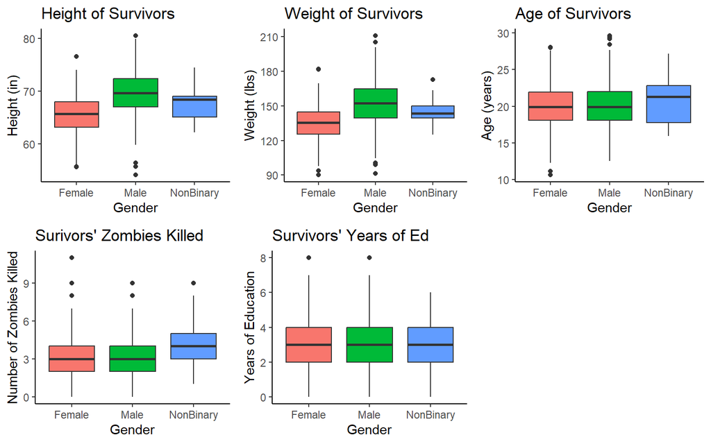

```r
heightbox <- ggplot(zombiedata, #create a plot using zombiedata
        aes(x=gender, y=height, fill=gender)) + #use gender as the x-axis and height as the y-axis. Fill the colors by gender
    geom_boxplot() + #make it a boxplot
    theme_classic() + #use theme_classic because it looks nicer than the default
    labs(title = "Height of Survivors", x = "Gender", y = "Height (in)") #label the title and axes
#Now rinse and repeat for the other plots
weightbox <- ggplot(zombiedata, aes(x=gender, y=weight, fill=gender)) + geom_boxplot() + theme_classic() +   labs(title = "Weight of Survivors",x = "Gender", y = "Weight (lbs)")
agebox <- ggplot(zombiedata, aes(x=gender, y=age, fill=gender)) + geom_boxplot() + theme_classic() + labs(title = "Age of Survivors",x = "Gender", y = "Age (years)")
zkbox <- ggplot(zombiedata, aes(x=gender, y=zombies_killed, fill=gender)) + geom_boxplot() + theme_classic() +   labs(title = "Surivors' Zombies Killed",x = "Gender", y = "Number of Zombies Killed")
yoebox <- ggplot(zombiedata, aes(x=gender, y=years_of_education, fill=gender)) + geom_boxplot() + theme_classic() +   labs(title = "Survivors' Years of Ed",x = "Gender", y = "Years of Education")

ggarrange(heightbox, weightbox, agebox, zkbox, yoebox,ncol = 3, nrow = 2, #Arrange all five plots into a 3x2 panel
          legend="none") #Don't show the legend for each plot because that's too busy and not necessary
```

## 3. Use {ggplot} to make scatterplots of height and weight in relation to age. Do these variables seem to be related? In what way?

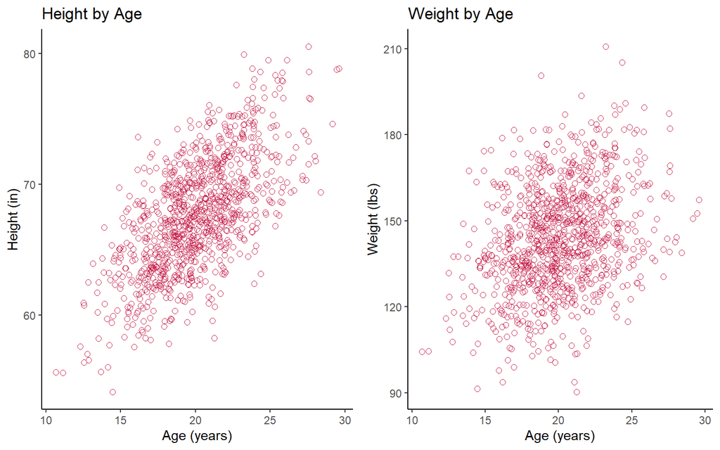

```r
heightagescatter <- ggplot(zombiedata, #create a plot using zombiedata
          aes(x=age, y=height)) + #use age as the x-axis and height as the y-axis
      geom_point(size=2, shape=1, color="#c7254e") + #make it a scatterplot and define the appearance of the points
      theme_classic() + #use theme_classic() because it looks nicer than the default
      labs(title = "Height by Age",x = "Age (years)", y = "Height (in)") #label the title and axes
#Repeat for weight
weightagescatter <- ggplot(zombiedata, aes(x=age, y=weight)) + geom_point(size=2, shape=1, color="#c7254e") + theme_classic() +   labs(title = "Weight by Age",x = "Age (years)", y = "Weight (lbs)")

ggarrange(heightagescatter, weightagescatter, #Arrange all five plots into a 3x2 panel
          ncol = 2, nrow = 1, legend="none") #Don't show the legend for each plot because that's too busy and not necessary
```

Age and height certainly seem to be related in that older survivors are taller. Age and weight also appear to be related in that older survivors seem to weigh more.

## 4. Using histograms and Q-Q plots, check whether the quantitative variables seem to be drawn from a normal distribution. Which seem to be and which do not (hint: not all are drawn from the normal distribution)? For those that are not normal, can you determine from which common distribution they are drawn?

#### Height

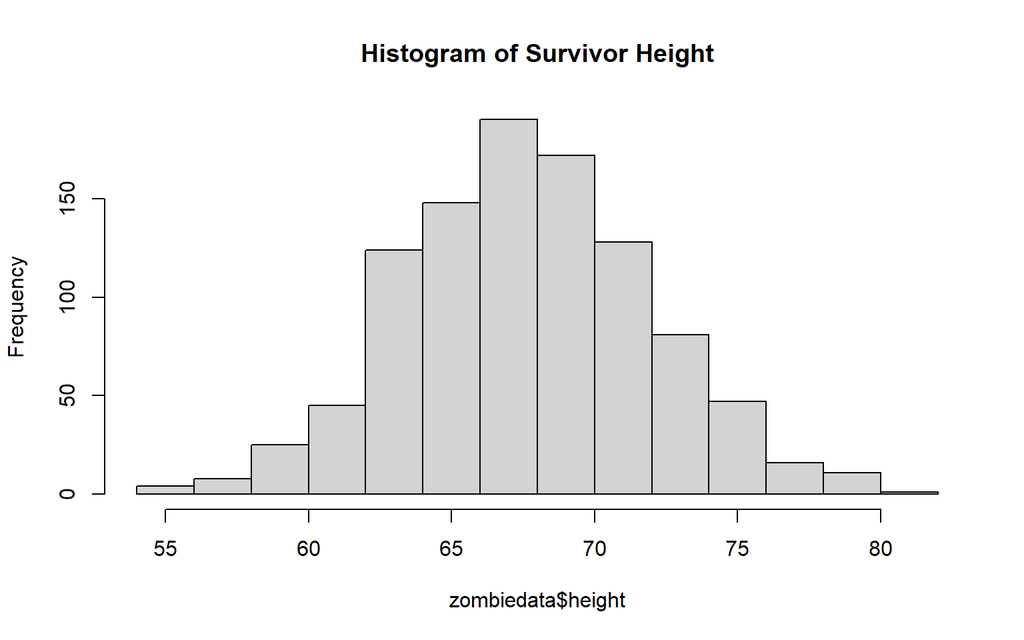

```r
hist(zombiedata$height, main = "Histogram of Survivor Height") #histogram
```

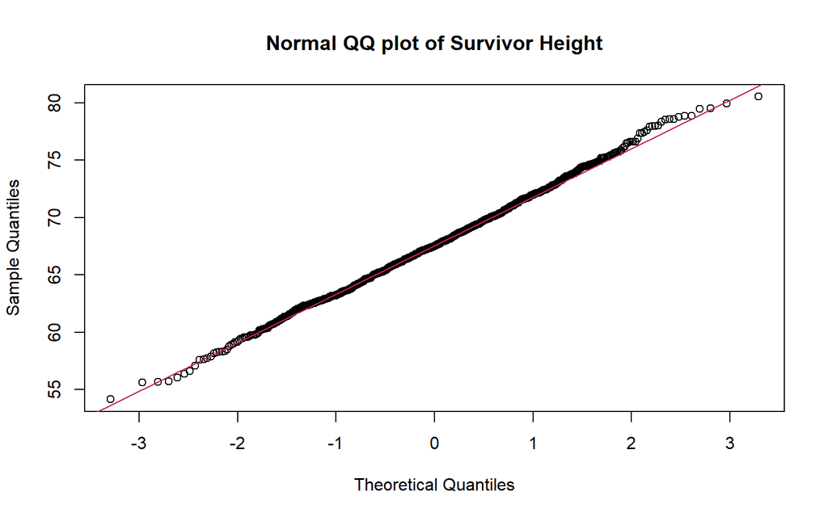

```r
qqnorm(zombiedata$height, main = "Normal QQ plot of Survivor Height") #q-q graph
qqline(zombiedata$height, col = "#c7254e")
```

Height appears to be normally distributed.

#### Weight

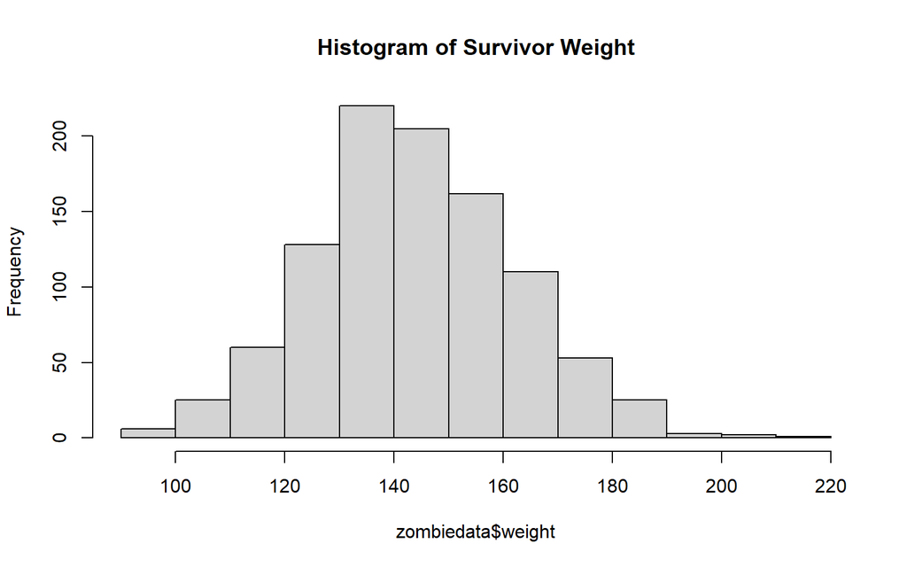

```r
hist(zombiedata$weight, main = "Histogram of Survivor Weight")
```

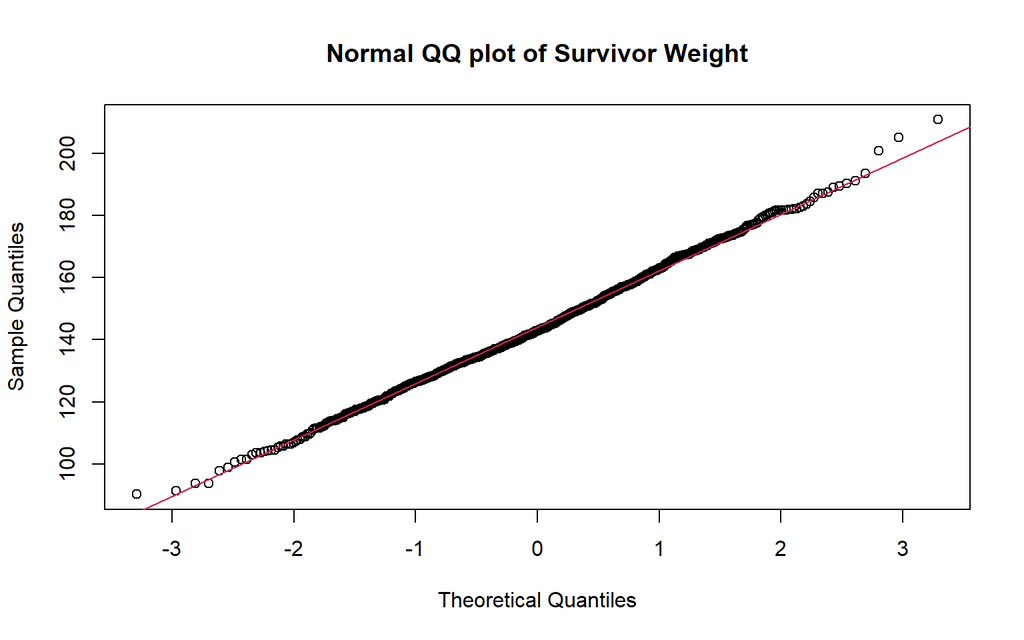

```r
qqnorm(zombiedata$weight, main = "Normal QQ plot of Survivor Weight")
qqline(zombiedata$weight, col = "#c7254e")
```

Weight appears to be normally distributed.

#### Age

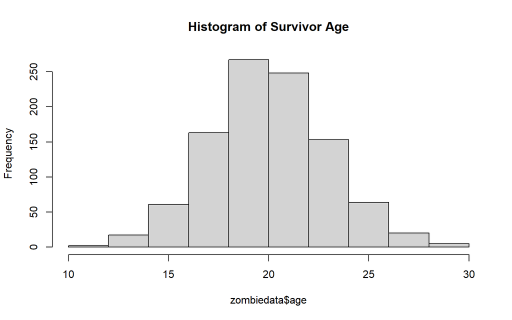

```r
hist(zombiedata$age, main = "Histogram of Survivor Age")
```

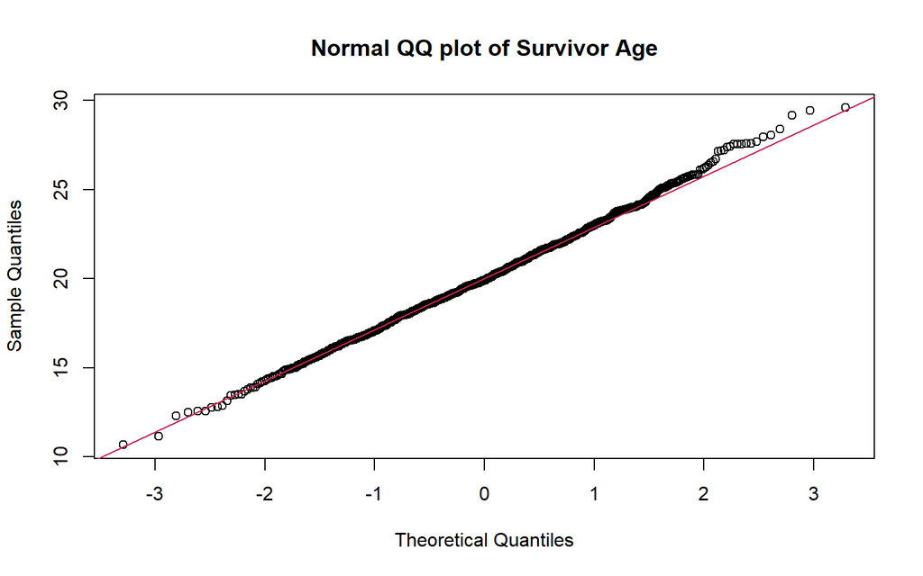

```r
qqnorm(zombiedata$age, main = "Normal QQ plot of Survivor Age")
qqline(zombiedata$age, col = "#c7254e")
```

Age appears to be drawn from a normal distribution.

#### Zombies Killed

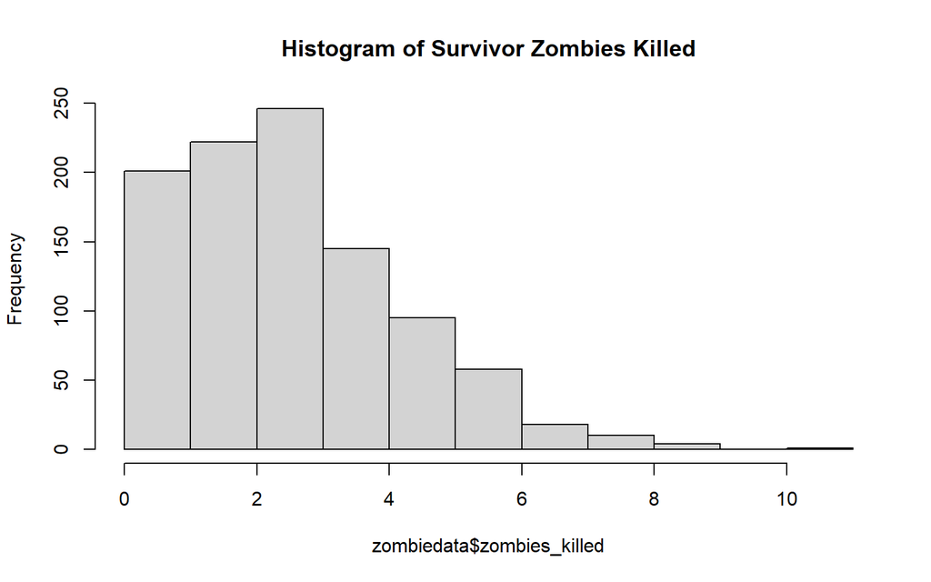

```r
hist(zombiedata$zombies_killed, main = "Histogram of Survivor Zombies Killed")
```

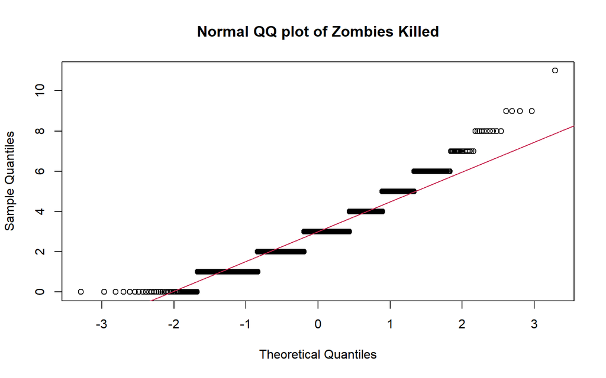

```r
qqnorm(zombiedata$zombies_killed, main = "Normal QQ plot of Zombies Killed")
qqline(zombiedata$zombies_killed, col = "#c7254e")
```

Number of zombies killed is definitely not normally distributed. It may be a poisson distribution since it is open ended counts of the independently occuring events of survivors having killed a certain number of zombies.

#### Years of Education

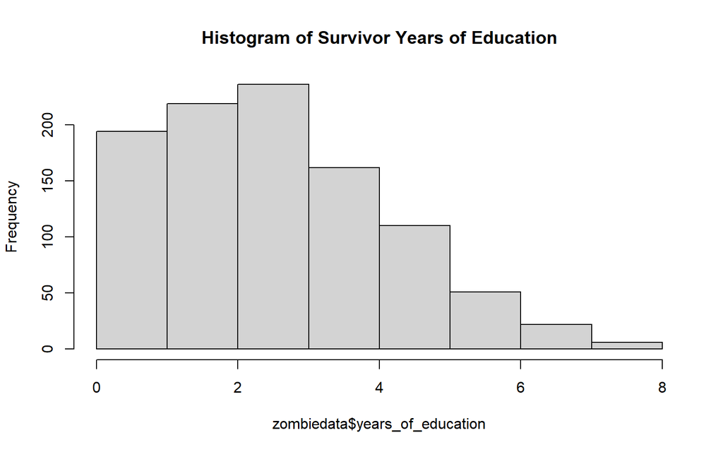

```r
hist(zombiedata$years_of_education, main = "Histogram of Survivor Years of Education")
```

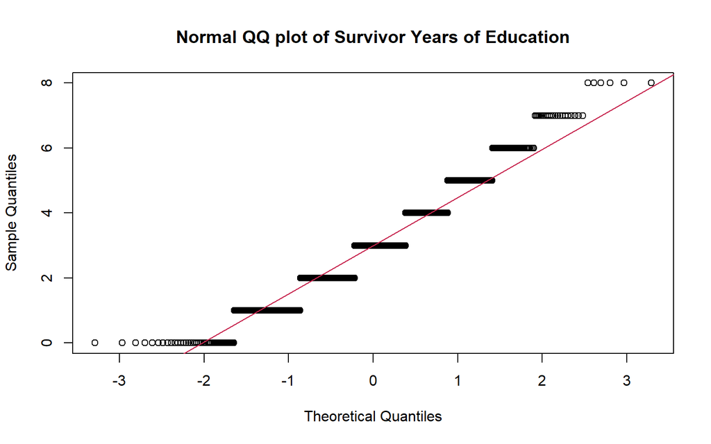

```r
qqnorm(zombiedata$years_of_education, main = "Normal QQ plot of Survivor Years of Education")
qqline(zombiedata$years_of_education, col = "#c7254e")
```

Years of education is definitely not normally distributed. It may be a poisson distribution since it is open ended counts of the independently occurring events of survivors having completed a certain number of years of education.

## 5. Now use the sample() function to sample ONE subset of 30 zombie survivors (without replacement) from this population and calculate the mean and sample standard deviation for each variable. Also estimate the standard error for each variable, and construct the 95% confidence interval for each mean. Note that for the variables that are not drawn from the normal distribution, you may need to base your estimate of the CIs on slightly different code than for the normal…

```r
library(dplyr)
set.seed(96) #set seed to any number so that every time you run this code, you get the same sample
sample30 <- sample_n(zombiedata, 30, replace=FALSE) #use sample_n() to sample whole rows from a dataframe. Using sample() can only sample from one vector like zombiedata$height. #replace=FALSE is the default, but why not specify it anyway, just to make sure.
head(sample30) #take a peek at the sample
```

```
##    id first_name last_name gender   height   weight zombies_killed
## 1 799      Brian  Crawford   Male 78.85808 157.3328              7
## 2   1      Sarah    Little Female 62.88951 132.0872              2
## 3 936      Linda   Garrett Female 63.35129 138.5302              3
## 4 431      Betty Patterson Female 68.26537 136.9853              2
## 5 959      Steve   Stanley   Male 62.53065 131.5167              2
## 6 525     Eugene   Stanley   Male 73.35391 187.1712              2
##   years_of_education             major      age
## 1                  2        psychology 29.59488
## 2                  1  medicine/nursing 17.64275
## 3                  4 culinart services 17.88162
## 4                  3        philosophy 21.89009
## 5                  4            botany 15.66170
## 6                  3  applied sciences 20.43760
```

### Define a general function to calculate confidence intervals (for normally distributed data only).

```r
normalSE = function(x) { #create a function
    se = sd(x)/sqrt(length(x)) #that calculates standard error
    return(se)}

normalCI = function(x, CIlevel = 0.95) { #create a function
    upper = mean(x) + qnorm(1 - (1 - CIlevel)/2) * sqrt(var(x)/length(x)) #that calculates upper and lower confidence intervals based on a normal distribution
    lower = mean(x) + qnorm((1 - CIlevel)/2) * sqrt(var(x)/length(x))
    ci <- c(lower, upper)
    return(ci)}
```

#### Height

```r
sample.height.mean <- mean(sample30$height) #mean of the sample
sample.height.stdev <- sd(sample30$height) #sd of the sample
sample.height.SE <- normalSE(sample30$height) #estimated standard error of the mean based on the sample
sample.height.CI <- normalCI(sample30$height, 0.95) #confidence interval of the sample mean

sample.height.mean
```

```
## [1] 68.07195
```

```r
sample.height.stdev
```

```
## [1] 4.895065
```

```r
sample.height.SE
```

```
## [1] 0.8937125
```

```r
sample.height.CI
```

```
## [1] 66.32030 69.82359
```

#### Weight

```r
sample.weight.mean <- mean(sample30$weight)
sample.weight.stdev <- sd(sample30$weight)
sample.weight.SE <- normalSE(sample30$weight)
sample.weight.CI <- normalCI(sample30$weight, 0.95)

sample.weight.mean
```

```
## [1] 143.993
```

```r
sample.weight.stdev
```

```
## [1] 20.94607
```

```r
sample.weight.SE
```

```
## [1] 3.824212
```

```r
sample.weight.CI
```

```
## [1] 136.4977 151.4883
```

#### Age

```r
sample.age.mean <- mean(sample30$age)
sample.age.stdev <- sd(sample30$age)
sample.age.SE <- normalSE(sample30$age)
sample.age.CI <- normalCI(sample30$age, 0.95)

sample.age.mean
```

```
## [1] 20.37631
```

```r
sample.age.stdev
```

```
## [1] 3.156387
```

```r
sample.age.SE
```

```
## [1] 0.5762748
```

```r
sample.age.CI
```

```
## [1] 19.24683 21.50579
```

### Define a general function to calculate confidence intervals for a poisson distribution. Is this even necessary? I do not know.

#### Zombies Killed

```r
poissonSE = function(x) { #create a function
    se = sqrt(mean(x)/length(x)) #that calculates standard error
    return(se)}

poissonCI = function(x, CIlevel = 0.95) { #create a function
    upper = mean(x) + qpois(1 - (1 - CIlevel)/2, lambda=mean(x)) * sqrt(mean(x)/length(x)) #that calculates upper and lower confidence intervals based on a poisson distribution with lambda/mean of the data
    lower = mean(x) + qpois((1 - CIlevel)/2, lambda=mean(x)) * sqrt(mean(x)/length(x))
    ci <- c(lower, upper)
    return(ci)}
```

```r
sample.zk.mean <- mean(sample30$zombies_killed)
sample.zk.stdev <- sd(sample30$zombies_killed)
sample.zk.SE <- poissonSE(sample30$zombies_killed)
sample.zk.CI <- poissonCI(sample30$zombies_killed)

sample.zk.mean
```

```
## [1] 3.433333
```

```r
sample.zk.stdev
```

```
## [1] 2.045741
```

```r
sample.zk.SE
```

```
## [1] 0.3382964
```

```r
sample.zk.CI
```

```
## [1] 3.433333 5.801408
```

#### Years of Education

```r
sample.yoe.mean <- mean(sample30$years_of_education)
sample.yoe.stdev <- sd(sample30$years_of_education)
sample.yoe.SE <- poissonSE(sample30$years_of_education)
sample.yoe.CI <- poissonCI(sample30$years_of_education)

sample.yoe.mean
```

```
## [1] 2.833333
```

```r
sample.yoe.stdev
```

```
## [1] 1.5105
```

```r
sample.yoe.SE
```

```
## [1] 0.3073181
```

```r
sample.yoe.CI
```

```
## [1] 2.833333 4.984560
```

## 6. Now draw 99 more random samples of 30 zombie apocalypse survivors, and calculate the mean for each variable for each of these samples. Together with the first sample you drew, you now have a set of 100 means for each variable (each based on 30 observations), which constitutes a sampling distribution for each variable. What are the means and standard deviations of this distribution of means for each variable? How do the standard deviations of means compare to the standard errors estimated in [5]? What do these sampling distributions look like (a graph might help here)? Are they normally distributed? What about for those variables that you concluded were not originally drawn from a normal distribution?

First, draw the samples.

```r
set.seed(4) #set seed so that everyone who runs this gets the same 99 samples
samples99 <- bind_rows(replicate(99, zombiedata %>% sample_n(30), simplify=F), .id="SampleID") #use replicate() to run sample_n() 99 times and use bind_rows() to put all those samples together into one dataframe
head(samples99)
```

```
##   SampleID  id first_name last_name gender   height   weight zombies_killed
## 1        1 504    Anthony       Day   Male 72.16500 167.3972              3
## 2        1 587    Michael     Berry   Male 73.02198 160.7283              2
## 3        1 819     Harold Patterson   Male 70.75748 152.3995              3
## 4        1 771     Bonnie  Peterson Female 66.51151 123.8688              8
## 5        1  71     Cheryl   Andrews Female 72.29987 168.0946              2
## 6        1 684  Christina  Harrison Female 66.81429 128.3871              3
##   years_of_education                 major      age
## 1                  3             logistics 21.88073
## 2                  3          pharmacology 22.56667
## 3                  0    physical education 21.43846
## 4                  1 agricultural sciences 21.10963
## 5                  3               biology 23.23299
## 6                  6                botany 25.32669
```

### Next, calculate the means of each variable for each sample.

#### Height

```r
sample_means_height <- samples99 %>% # Specify data frame
    group_by(SampleID) %>% # Specify group indicator column
    summarise_at(vars(height), list(Mean_height = mean)) # Calculate the mean of the "height" column for each group
head(sample_means_height)
```

```
## # A tibble: 6 × 2
##   SampleID Mean_height
##   <chr>          <dbl>
## 1 1               67.4
## 2 10              65.8
## 3 11              67.5
## 4 12              69.1
## 5 13              67.4
## 6 14              66.5
```

#### Weight

```r
sample_means_weight <- samples99 %>%
    group_by(SampleID) %>%
    summarise_at(vars(weight), list(Mean_weight = mean))
head(sample_means_weight)
```

```
## # A tibble: 6 × 2
##   SampleID Mean_weight
##   <chr>          <dbl>
## 1 1               144.
## 2 10              136.
## 3 11              141.
## 4 12              151.
## 5 13              143.
## 6 14              138.
```

#### Age

```r
sample_means_age <- samples99 %>%
    group_by(SampleID) %>%
    summarise_at(vars(age), list(Mean_age = mean))
head(sample_means_age)
```

```
## # A tibble: 6 × 2
##   SampleID Mean_age
##   <chr>       <dbl>
## 1 1            20.1
## 2 10           19.8
## 3 11           19.9
## 4 12           20.3
## 5 13           20.5
## 6 14           20.0
```

#### Zombies Killed

```r
sample_means_zk <- samples99 %>%
    group_by(SampleID) %>%
    summarise_at(vars(zombies_killed), list(Mean_zk = mean))
head(sample_means_zk)
```

```
## # A tibble: 6 × 2
##   SampleID Mean_zk
##   <chr>      <dbl>
## 1 1           3.07
## 2 10          2.73
## 3 11          2.33
## 4 12          2.9
## 5 13          2.47
## 6 14          3
```

#### Years of Education

```r
sample_means_yoe <- samples99 %>%
    group_by(SampleID) %>%
    summarise_at(vars(years_of_education), list(Mean_yoe = mean))
head(sample_means_yoe)
```

```
## # A tibble: 6 × 2
##   SampleID Mean_yoe
##   <chr>       <dbl>
## 1 1            2.43
## 2 10           3.13
## 3 11           3.43
## 4 12           3.33
## 5 13           2.87
## 6 14           2.6
```

Combine all 99 means into one dataframe just to have them all in one spot.

```r
library(tidyverse) #load tidyverse to use reduce() function
all_sample_means_list <- list(sample_means_height, sample_means_weight, sample_means_age, sample_means_zk, sample_means_yoe) #combine all data frames in a list

all_sample_means <- all_sample_means_list %>% reduce(full_join, by='SampleID') #merge that list into one dataframe using reduce()
head(all_sample_means)
```

```
## # A tibble: 6 × 6
##   SampleID Mean_height Mean_weight Mean_age Mean_zk Mean_yoe
##   <chr>          <dbl>       <dbl>    <dbl>   <dbl>    <dbl>
## 1 1               67.4        144.     20.1    3.07     2.43
## 2 10              65.8        136.     19.8    2.73     3.13
## 3 11              67.5        141.     19.9    2.33     3.43
## 4 12              69.1        151.     20.3    2.9      3.33
## 5 13              67.4        143.     20.5    2.47     2.87
## 6 14              66.5        138.     20.0    3        2.6
```

Also add that first sample taken in Question 5 as a 100th row.

```r
row100 = c(SampleID=100, Mean_height=sample.height.mean, Mean_weight=sample.weight.mean, Mean_age=sample.age.mean, Mean_zk=sample.zk.mean, Mean_yoe=sample.yoe.mean) #create a row of the means of each variable from the sample in question 5
hundred_sample_means = rbind(all_sample_means,row100) #bind the new row to the old dataframe of 99 samples to create a new one with 100 samples
str(hundred_sample_means) #check the structure to see that there are now 100 entries for each column
```

```
## tibble [100 × 6] (S3: tbl_df/tbl/data.frame)
##  $ SampleID   : chr [1:100] "1" "10" "11" "12" ...
##  $ Mean_height: num [1:100] 67.4 65.8 67.5 69.1 67.4 ...
##  $ Mean_weight: num [1:100] 144 136 141 151 143 ...
##  $ Mean_age   : num [1:100] 20.1 19.8 19.9 20.3 20.5 ...
##  $ Mean_zk    : num [1:100] 3.07 2.73 2.33 2.9 2.47 ...
##  $ Mean_yoe   : num [1:100] 2.43 3.13 3.43 3.33 2.87 ...
```

### What are the means and standard deviations of this distribution of means for each variable? How do the standard deviations of means compare to the standard errors estimated in [5]?

#### Height

```r
heights100_mean <- mean(hundred_sample_means$Mean_height) #mean of all the height sample means
heights100_stdev <- sd(hundred_sample_means$Mean_height) #stdev of all the height samples means

heights100_mean
```

```
## [1] 67.59433
```

```r
heights100_stdev
```

```
## [1] 0.8036928
```

The standard error of the mean calculated in question 5 was 0.8937125 which is fairly close to the standard deviation of the means 0.8036928.

#### Weight

```r
weights100_mean <- mean(hundred_sample_means$Mean_weight)
weights100_stdev <- sd(hundred_sample_means$Mean_weight)

weights100_mean
```

```
## [1] 143.58
```

```r
weights100_stdev
```

```
## [1] 3.525196
```

The standard error of the mean calculated in question 5 was 3.824212 which is fairly close to the standard deviation of the means 3.525196.

#### Age

```r
ages100_mean <- mean(hundred_sample_means$Mean_age)
ages100_stdev <- sd(hundred_sample_means$Mean_age)

ages100_mean
```

```
## [1] 20.02749
```

```r
ages100_stdev
```

```
## [1] 0.5254162
```

The standard error of the mean calculated in question 5 was 0.5762748 which is fairly close to the standard deviation of the means 0.5254162.

#### Zombies Killed

```r
zk100_mean <- mean(hundred_sample_means$Mean_zk)
zk100_stdev <- sd(hundred_sample_means$Mean_zk)

zk100_mean
```

```
## [1] 2.995333
```

```r
zk100_stdev
```

```
## [1] 0.3042542
```

The standard error of the mean calculated in question 5 was 0.3382964 which is fairly close to the standard deviation of the means 0.3042542.

#### Years of Education

```r
yoe100_mean <- mean(hundred_sample_means$Mean_yoe)
yoe100_stdev <- sd(hundred_sample_means$Mean_yoe)

yoe100_mean
```

```
## [1] 2.938
```

```r
yoe100_stdev
```

```
## [1] 0.2764217
```

The standard error of the mean calculated in question 5 was 0.3073181 which is kind of close to the standard deviation of the means 0.2764217

### What do these sampling distributions look like (a graph might help here)? Are they normally distributed? What about for those variables that you concluded were not originally drawn from a normal distribution?

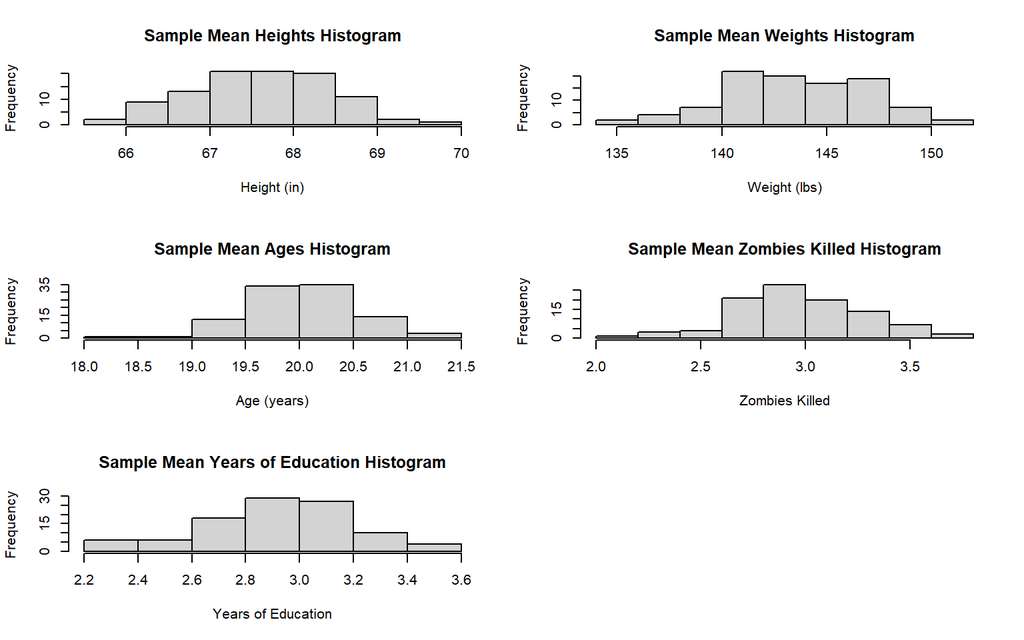

```r
par( mfrow= c(3, 2))
hist(hundred_sample_means$Mean_height, main = "Sample Mean Heights Histogram", xlab = "Height (in)")
hist(hundred_sample_means$Mean_weight, main = "Sample Mean Weights Histogram", xlab = "Weight (lbs)")
hist(hundred_sample_means$Mean_age, main = "Sample Mean Ages Histogram", xlab = "Age (years)")
hist(hundred_sample_means$Mean_zk, main = "Sample Mean Zombies Killed Histogram", xlab = "Zombies Killed")
hist(hundred_sample_means$Mean_yoe, main = "Sample Mean Years of Education Histogram", xlab = "Years of Education")
```

All the distributions of means appear to be normally distributed, even the ones that were not originally drawn from a normal distribution. This is because the deviations from the actual mean are normally distributed.